title: “MITx15.071x-U1-Recitation-Summary Tables.Rmd” author: “Rahul Yadav” date: “April 14, 2016” output: html_document —

## Refresher

#### In Previous recitation, we did the following:

#### Created new variables.

#### Added to our data frame “USDA”.

#### These variables were namely:

#### HighSodium.

#### HighFat.

#### HighCarbs.

#### HighProtein.

## Outline

#### In this session, we are going to discuss the following things:

#### Understanding our data more closely.

#### Identifying relationships b/w our variables.

#### How? By using **table()** & **tapply()** functions.

#### Answering the following question:

#### To figure out how many foods have High Sodium level than average?

#### By looking at the HighSodium variable and count the foods that have value 1.

## Analysis

Let’s find out how many food have High Sodium content and How many doesn’t.

```r
# Loading our data set.

USDA <- read.csv("C:/Users/pySag/Desktop/MITx15.071x/Datasets/USDA.csv")
str(USDA)
```

```
## 'data.frame':    7058 obs. of  25 variables:
##  $ X.4         : int  1 2 3 4 5 6 7 8 9 10 ...
##  $ X.3         : int  1 2 3 4 5 6 7 8 9 10 ...
##  $ X.2         : int  1 2 3 4 5 6 7 8 9 10 ...
##  $ X.1         : int  1 2 3 4 5 6 7 8 9 10 ...
##  $ X           : int  1 2 3 4 5 6 7 8 9 10 ...
##  $ ID          : int  1001 1002 1003 1004 1005 1006 1007 1008 1009 1010 ...
##  $ Description : Factor w/ 7054 levels "ABALONE,MIXED SPECIES,RAW",..: 1303 1302 1298 2303 2304 2305 2306 2307 2308 2309 ...
##  $ Calories    : int  717 717 876 353 371 334 300 376 403 387 ...
##  $ Protein     : num  0.85 0.85 0.28 21.4 23.24 ...
##  $ TotalFat    : num  81.1 81.1 99.5 28.7 29.7 ...
##  $ Carbohydrate: num  0.06 0.06 0 2.34 2.79 0.45 0.46 3.06 1.28 4.78 ...
##  $ Sodium      : int  714 827 2 1395 560 629 842 690 621 700 ...
##  $ SaturatedFat: num  51.4 50.5 61.9 18.7 18.8 ...
##  $ Cholesterol : int  215 219 256 75 94 100 72 93 105 103 ...
##  $ Sugar       : num  0.06 0.06 0 0.5 0.51 0.45 0.46 NA 0.52 NA ...
##  $ Calcium     : int  24 24 4 528 674 184 388 673 721 643 ...
##  $ Iron        : num  0.02 0.16 0 0.31 0.43 0.5 0.33 0.64 0.68 0.21 ...
##  $ Potassium   : int  24 26 5 256 136 152 187 93 98 95 ...
##  $ VitaminC    : num  0 0 0 0 0 0 0 0 0 0 ...
##  $ VitaminE    : num  2.32 2.32 2.8 0.25 0.26 0.24 0.21 NA 0.29 NA ...
##  $ VitaminD    : num  1.5 1.5 1.8 0.5 0.5 0.5 0.4 NA 0.6 NA ...
##  $ HighSodium  : int  1 1 0 1 1 1 1 1 1 1 ...
##  $ HighProtein : int  0 0 0 1 1 1 1 1 1 1 ...
##  $ HighFat     : int  1 1 1 1 1 1 1 1 1 1 ...
##  $ HighCarb    : int  0 0 0 0 0 0 0 0 0 0 ...
```

```r
# Counting High Sodium values.

table(USDA $ HighSodium)
```

```
##
##    0    1
## 4884 2090
```

```r
# Let's see how many foods have both high sodium & high fat.

table(USDA $ HighSodium, USDA $ HighFat)
```

```
##
##        0    1
##   0 3529 1355
##   1 1378  712
```

```r
## 1st row belogs to 1st input argument and coloumn correspond to 2nd input.
```

#### **[ INFERENCE ]:** Interpreting our previous result as follows:

#### 3,529 foods ———– **low** sodium & **low** fat.

#### 1,355 foods ———– **low** sodium but **high** fat.

#### 1,378 foods ———– **high** sodium but **low** fat.

#### 712 foods ———– **both**, **high** sodium & **high** fat.

#### What if we want to compute the average amount of iron sorted by high and low protein?

#### We can do this by following way:

#### Using tapply() to extract info on iron variable in our USDA data frame.

#### Then providing 2nd arguments as both high and low protein.

#### Followed by a 3rd argument, mean.

#### Lets take this for a spin in our r chunk.

```r
# Lets compute the avg. amount of Iron sorted by Protein levels.
tapply( USDA $ Iron, USDA $ HighProtein, mean, na.rm = TRUE)
```

```
##        0        1
## 2.558945 3.197294
```

```r
# Now, lets compute the max. amount of "Vitamin C" sorted by high & low Carbohydrate

tapply( USDA $ VitaminC, USDA $ HighCarb, max, na.rm = TRUE)
```

```
##      0      1
## 1677.6 2400.0
```

#### **Inference:** What exactly does **tapply** do?

### **The following observations are made:**

#### The first tapply() computes the average amount of Iron sorted by High Protein levels.

#### The 2nd tapply() computes the maximum amount of “VitaminC” sorted by High & Low Carbohydrates.

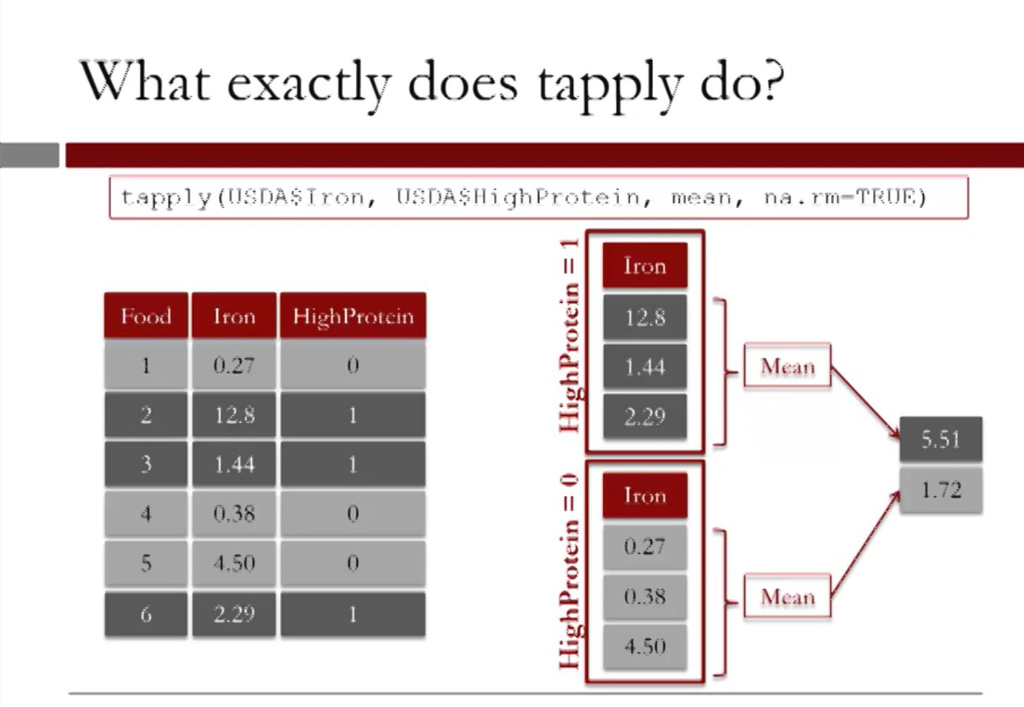

#### **How about investigating whether food with High Carbs have generally High Vitamin C content or vice-versa?**

#### To do this, we will make just a small change in our previous code.

#### Instead Using ‘max’ function, we will use ‘summary’.

#### This will give us a statistical info or clear picture to support or reject our claim.

```r
tapply( USDA $ VitaminC, USDA $ HighCarb, summary, na.rm = TRUE)
```

```
## $`0`
##     Min.  1st Qu.   Median     Mean  3rd Qu.     Max.     NA's
##    0.000    0.000    0.000    6.364    2.800 1678.000      248
##
## $`1`
##    Min. 1st Qu.  Median    Mean 3rd Qu.    Max.    NA's
##    0.00    0.00    0.20   16.31    4.50 2400.00      83
```

## **Conclusion**

#### From the former results, we can say the following:

#### *In general, Foods with High Carbs are on average richer in vitamin C*

#### As compared to foods with Low Carbs content.